# Theory Assignment Residuals

```r
dat <- read_csv("weatherPredDat.csv", show_col_types = FALSE)

dat_comb <- dat %>%
  mutate(
    explan = round((High_Temp / Wind_Speed / Weather), 2)
  ) %>%
  filter(explan < 15)

weath_lm <- lm(dat_comb$Two_DL~dat_comb$explan)
```

## Residuals

#### Equation

$$r_i = Y_i - \hat{Y}_i$$

#### Graph

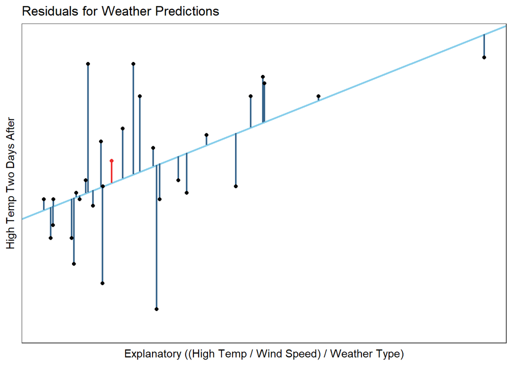

```r
b <- coef(weath_lm)

x_bar <- 51 / 7 / 3
y_bar <- round((b[1] + b[2] * x_bar),2)

ggplot() +
  geom_abline(slope=b[2], intercept=b[1], linewidth=.8, color="skyblue") +
  theme_bw() +
  theme(panel.grid = element_blank(),
        axis.text = element_blank(),
        axis.ticks = element_blank()) +
  geom_segment(data=dat_comb, aes(x=explan, xend=explan, y=Two_DL, yend=weath_lm$fit), color="steelblue4", linewidth=.8) +
  geom_point(data=dat_comb, mapping=aes(x=explan, y=Two_DL)) +
  geom_point(aes(x=x_bar, y=61), color="firebrick2") +
  geom_segment(aes(x=x_bar, xend=x_bar, y=61, yend=y_bar), color="firebrick2", linewidth=.8) +
  labs(
    x = "Explanatory ((High Temp / Wind Speed) / Weather Type)",
    y = "High Temp Two Days After",
    title = "Residuals for Weather Predictions"
  ) +
  coord_cartesian(ylim=c(35, 80))
```

#### Explanation

Residuals are unique for each point on the graph and represent the difference between the **Actual Y value** and the **Predicted Y value**.

There are many uses to residuals, even if you just have one. You can tell how far away the prediction is for that single point and whether you predicted above or below based on if the residual is positive or negative. If the residual is **negative then the prediction is too high** and if the residual is **positive then the prediction is too low**.

Above for the residual graph we can see the red line which symbolizes the residual for a weather prediction. The prediction on the line was **57.6** while the actual value was **61**. So the residual would be **61 - 57.6**, which equals **3.4**. We can see that the prediction was too low in this case.

## Sum of Squares (SSE, SSR, and SSTO)

### **Sum of Squared Errors (SSE)**

#### Equation

$$SSE = \sum_{i=1}^n (Y_i - \hat{Y}_i)^2$$

$$SSE + SSR = SSTO$$

#### Graph

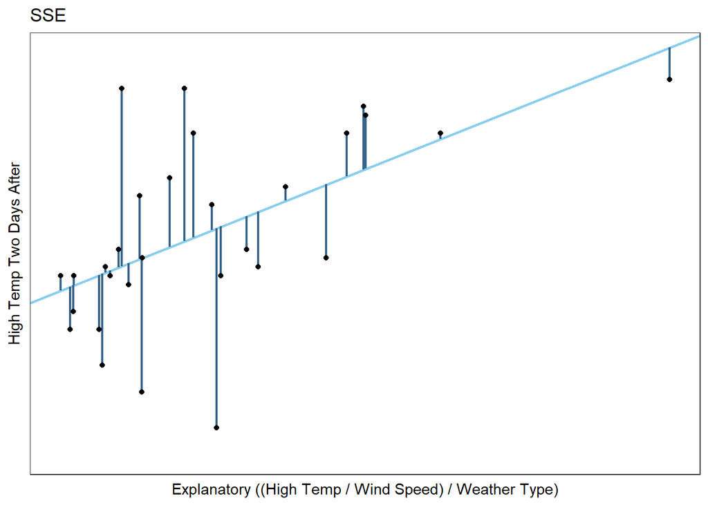

```r
sse <- round(sum((dat_comb$Two_DL - weath_lm$fit)^2),2) ## SSE


ggplot() +
  geom_abline(linewidth=.8, color="skyblue", aes(slope=b[2], intercept=b[1])) +
  geom_segment(data=dat_comb, aes(x=explan, xend=explan, y=Two_DL, yend=weath_lm$fit), color="steelblue4", linewidth=.8) +
  geom_point(data=dat_comb, mapping=aes(x=explan, y=Two_DL)) +
  labs(
    x = "Explanatory ((High Temp / Wind Speed) / Weather Type)",
    y = "High Temp Two Days After",
    title = "SSE",
  ) +
  coord_cartesian(ylim=c(35, 80)) +
  theme_bw() +
  theme(panel.grid = element_blank(),
        axis.text = element_blank(),
        axis.ticks = element_blank())
```

#### Explanation

SSE is the **Sum of Squared Errors** and, as is in the title, it is the sum of squared errors. The equation above may seem imposing but it is simple and is similar to the residuals in the above section. For every **actual Y value** you subtract the **predicted Y value** and square it, then you sum the squares. This gives you the **Sum of Squared Errors**!

We use this value to show the amount of deviation within the residuals, since it shows the residuals squared. We get the squared value so that we can see the total amount of residuals, since the sum of all residuals would equal zero if we didn’t square them first.

We can also use this value to calculate the R-Squared value, which shows the proportion of variance in Y that we can explain through our model. The **lower the value of SSE** is compared to SSR the closer to 1 the R-Squared value will be. The value can get to 0 but not negative, and as big as the SSTO. This is because SSE + SSR = SSTO.

The SSE in this instance would be:

$$\sum_{i=1}^{29} (\text{Two_DL}_i - \text{Predicted}_i)^2 = 2131.29$$

### **Sum of Squares Regression (SSR)**

#### Equation

$$SSR = \sum_{i=1}^n (\hat{Y}_i - \bar{Y})^2$$

$$SSR + SSE = SSTO$$

#### Graph

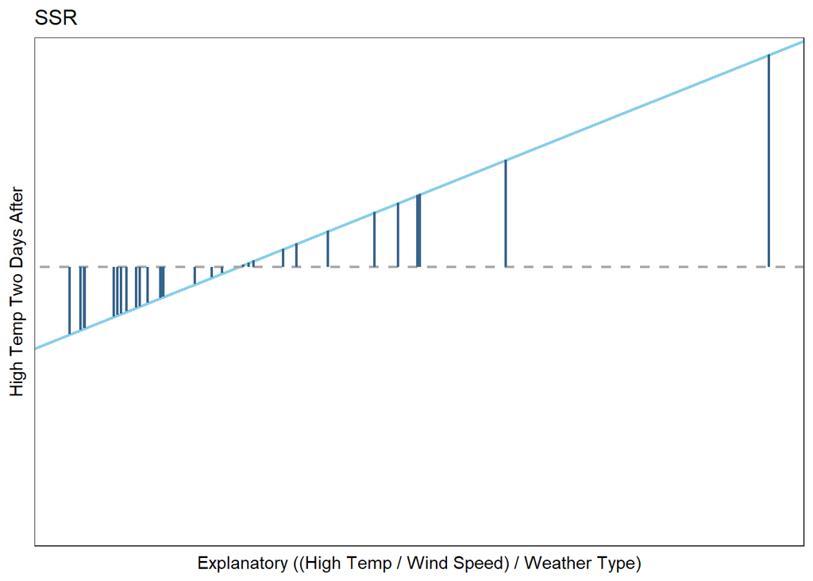

```r
ssr <- round(sum((weath_lm$fit - mean(dat_comb$Two_DL))^2),2) ## SSR

ggplot() +
  geom_abline(aes(slope=b[2], intercept=b[1]), linewidth=.8, color="skyblue") +
  geom_abline(aes(slope=0, intercept=mean(dat_comb$Two_DL)), linewidth=.8, color="darkgray", linetype=2) +
  geom_segment(data=dat_comb, aes(x=explan, xend=explan, y=mean(Two_DL), yend=weath_lm$fit), color="steelblue4", linewidth=.8) +
  labs(
    x = "Explanatory ((High Temp / Wind Speed) / Weather Type)",
    y = "High Temp Two Days After",
    title = "SSR",
  ) +
  coord_cartesian(ylim=c(35, 80)) +
  theme_bw() +
  theme(panel.grid = element_blank(),
        axis.text = element_blank(),
        axis.ticks = element_blank())
```

#### Explanation

SSR is the **Sum of Squares Regression**. The equation above shows us that for every **predicted Y value** you subtract the **mean of the actual Y values** and square it, then you sum the squares. This gives you the **Sum of Squares Regression**!

We use this value to show the amount of deviation between the regression line and the mean of the Y values, thus the Sum of Squares **Regression**. We get the squared value so that we can see the total amount of deviation.

We can also use this value to calculate the R-Squared value, which shows the proportion of variance in Y that we can explain through our model. The **higher the value of SSR** is compared to SSE the closer to 1 the R-Squared value will be. The value can get to 0 but not negative, and as big as the SSTO. This is because SSR + SSE = SSTO.

The SSR in this instance would be:

$$\sum_{i=1}^{29} (\text{Predicted}_i - \text{Mean Two_DL})^2 = 1033.4$$

### **Total Sum of Squares (SSTO)**

#### Equation

$$SSTO = \sum_{i=1}^n (Y_i - \bar{Y})^2$$

$$SSTO = SSE + SSR$$

#### Graph

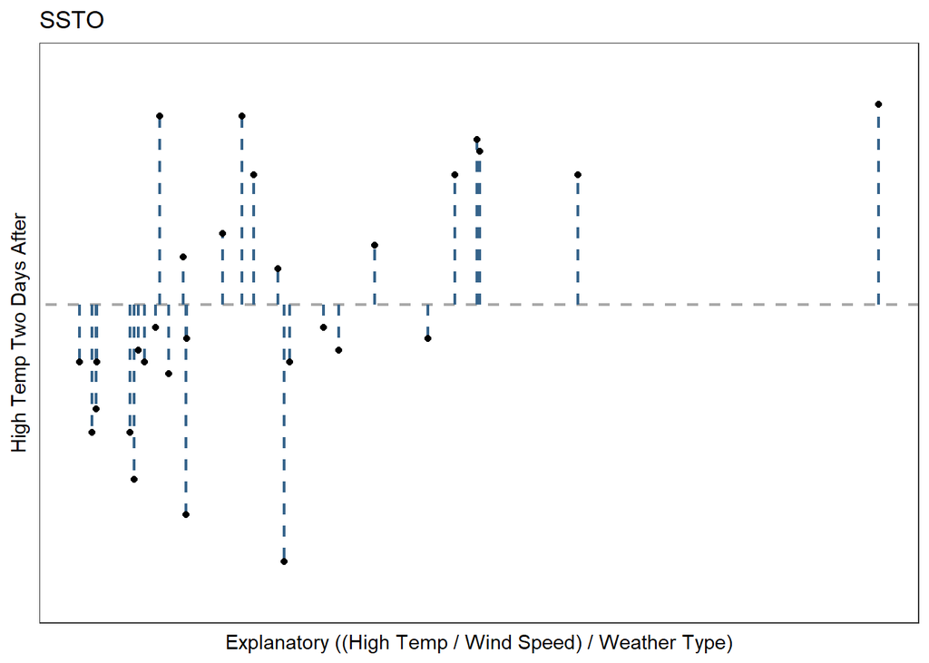

```r
ssto <- round(sum((dat_comb$Two_DL - mean(dat_comb$Two_DL))^2),2) ## SSTO

ggplot() +
  geom_abline(slope=0, intercept=mean(dat_comb$Two_DL), linetype=2, color="darkgray", linewidth=.8) +
  geom_segment(data=dat_comb, aes(x=explan, xend=explan, y=mean(Two_DL), yend=Two_DL), color="steelblue4", linewidth=.8, linetype=2) +
  geom_point(data=dat_comb, mapping=aes(x=explan, y=Two_DL)) +
  labs(
    x = "Explanatory ((High Temp / Wind Speed) / Weather Type)",
    y = "High Temp Two Days After",
    title = "SSTO",
  ) +
  coord_cartesian(ylim=c(35, 80)) +
  theme_bw() +
  theme(panel.grid = element_blank(),
        axis.text = element_blank(),
        axis.ticks = element_blank())
```

#### Explanation

SSTO is the **Total Sum of Squares**. The equation above shows us that for every **actual Y value** you subtract the **mean of the actual Y values** and square it, then you sum the squares. This gives you the **Total Sum of Squares**! It is called the total sum of squares because it is both the SSE and SSR combined.

We use this value to show the amount of deviation between the actual y values and the mean of the Y values. We get the squared value so that we can see the total amount of deviation, since the sum would be zero if you just combined the differences.

We can also use this value to calculate the R-Squared value, which shows the proportion of variance in Y that we can explain through our model. It doesn’t really matter if the SSTO is bigger or smaller because what matters is the proportion to SSE or SSR. So the **closer it is to SSR** and **further away it is from SSE** the closer the R-Squared value will be to 1. The value can get to 0 but not negative, and as big as SSE + SSR. This is because SSR + SSE = SSTO.

The SSTO in this instance would be:

$$\sum_{i=1}^{29} (\text{Two_DL}_i - \text{Mean Two_DL})^2 = 3164.69$$

We can also see that SSE plus SSR does equal SSTO:

$$2131.29(SSE) + 1033.4(SSR) =
3164.69(SSTO)$$

This shows that we will have a poor R-Squared value because the SSE is twice as large as the SSR.

## $R^2$

#### Equation

$$R^2 = \frac{SSR}{SSTO} = 1 - \frac{SSE}{SSTO}$$

#### Graph

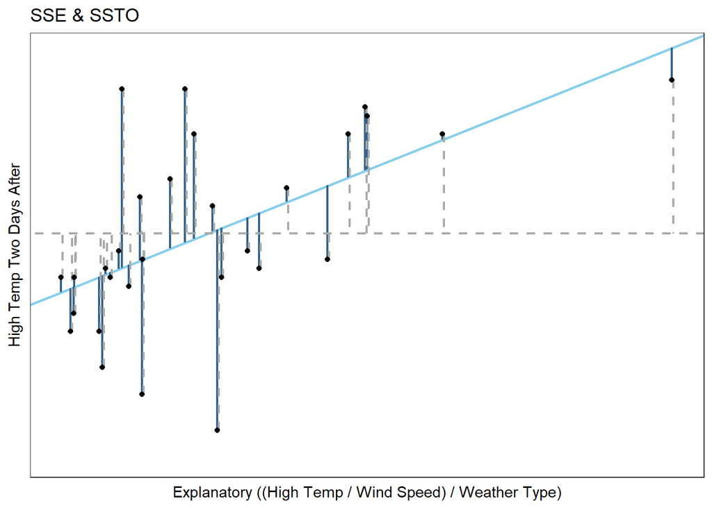

```r
b <- coef(weath_lm)

ggplot() +
  geom_abline(slope=b[2], intercept=b[1], linewidth=.8, color="skyblue") +
  theme_bw() +
  theme(panel.grid = element_blank(),
        axis.text = element_blank(),
        axis.ticks = element_blank()) +
  geom_segment(data=dat_comb, aes(x=explan, xend=explan, y=Two_DL, yend=weath_lm$fit), color="steelblue4", linewidth=.8) +
  geom_abline(slope=0, intercept=mean(dat_comb$Two_DL), linetype=2, color="darkgrey", linewidth=.8) +
  geom_segment(data=dat_comb, aes(x=explan+.03, xend=explan+.03, y=Two_DL, yend=mean(Two_DL)), color="darkgrey", linewidth=.8, linetype=2) +
  geom_point(data=dat_comb, mapping=aes(x=explan, y=Two_DL)) +
  labs(
    x = "Explanatory ((High Temp / Wind Speed) / Weather Type)",
    y = "High Temp Two Days After",
    title = "SSE & SSTO"
  ) +
  coord_cartesian(ylim=c(35, 80))
```

#### Explanation

The **R-Squared value** is useful for telling the proportion of the variance in Y, in this case the High Temperature in Two Days, that can be explained by our model, in this case the (High Temp/ Wind Speed)/ Weather Type.

The variance is what was being discussed in the Sum of Squares section, it is the distance the points are away from the regression line compared to the distance they are from the mean of actual Y values.

In the above graph, the blue lines represent the SSE before they are squared while the dashed lines represent the SSTO before they are squared. Because both the SSE and SSTO are high it shows that we have a low R-Squared. Another way to judge is how far away the points are from the regression line, because they are far away from the regression line we can also tell that the R-Squared is low.

The R-Squared value is not in the same units as the value being predicted or the Y value, because it is the result of the proportion of two numbers. However, it is still helpful in that since, just not in telling the sum of errors in terms of similar units.

The R-Squared differs from the p-value because the **p-value is testing that the regression line deviates from the average Y value** and the **R-Squared is seeing how the SSR differs proportionally from the SSTO**.

```r
r2 <- round(sum((weath_lm$fit - mean(dat_comb$Two_DL))^2) / sum((dat_comb$Two_DL - mean(dat_comb$Two_DL))^2),2)

mse <- round(sum((dat_comb$Two_DL - weath_lm$fit)^2)/(nrow(dat_comb)-2),2)

rse <- round(sqrt(sum((dat_comb$Two_DL - weath_lm$fit)^2)/(nrow(dat_comb)-2)),2)
```

The R-Squared in this instance would be:

$$1 - \frac{2131.29(SSE)}{3164.69(SSTO)} =
0.33(R^2)$$

## Mean Squared Error (MSE)

#### Equation

$$s^2 = MSE = \frac{SSE}{n - 2} = \frac{\sum_{i=1}^{n} (\text{Y}_i -
\hat{Y}_i)^2}{n - 2} = \frac{\sum_{i=1}^{n} \text{r}^2_i}{n - 2}$$

Each of these equations is essentially the same, since the residual, r, equals **actual Y minus predicted Y**. So the sum of squared **residuals** is the same as the **Sum of Squared Errors**.

#### Graph

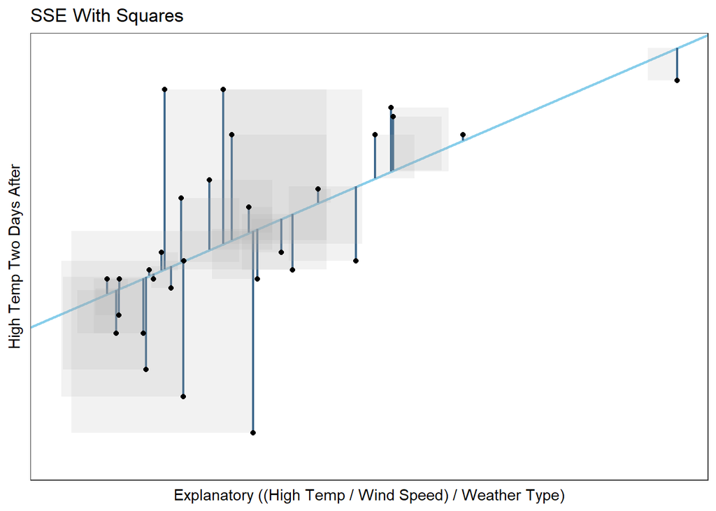

```r
sse <- round(sum((dat_comb$Two_DL - weath_lm$fit)^2),2) ## SSE


ggplot() +
  geom_abline(linewidth=.8, color="skyblue", aes(slope=b[2], intercept=b[1])) +
  geom_segment(data=dat_comb, aes(x=explan, xend=explan, y=Two_DL, yend=weath_lm$fit), color="steelblue4", linewidth=.8) +
  geom_rect(data=dat_comb, aes(xmin=explan, xmax=explan+(weath_lm$residuals*.165), ymin=Two_DL, ymax=weath_lm$fit), fill="darkgray", linewidth=.8, alpha=.15) +
  geom_point(data=dat_comb, mapping=aes(x=explan, y=Two_DL)) +
  labs(
    x = "Explanatory ((High Temp / Wind Speed) / Weather Type)",
    y = "High Temp Two Days After",
    title = "SSE With Squares",
  ) +
  coord_cartesian(ylim=c(35, 80)) +
  theme_bw() +
  theme(panel.grid = element_blank(),
        axis.text = element_blank(),
        axis.ticks = element_blank())
```

#### Explanation

The **Mean Squared Error** is the equivalent to the squared standard deviation in t-tests. The MSE doesn’t help a lot with interpreting the R-Squared; however, it helps when trying to decrease errors because it increases quickly as errors increase. How large the MSE is also depends on the units that are being used in the linear model. If we are predicting housing prices we can expect the MSE to be large because houses tend to cost a lot, or if we are predicting the size a spider will grow based off of how much it eats then it could be very small since spiders are small. However, generally the smaller the MSE the smaller the error sum is.

What does help and is in the units of the Y values is the **Residual Standard Error** or the **Root Mean Squared Error** since it is the square root of the MSE. This is the equivalent to the standard deviation in t-tests. This helps to make confidence intervals for predictions. And allows us to see the mean error sum in a more familiar way, since it is in the units that we are using.

The above graph shows the visual for the SSE, the squares represent each of the error terms squared. This is what the Mean Squared Error uses to get the mean, thus the name Mean Squared Error.

The MSE in this instance would be:

$$\frac{2131.29(SSE)}{29 - 2} = 78.94$$

The residual standard error would be:

$$\sqrt{78.94(MSE)} = 8.88$$

The MSE is almost 79, which is a lot when we are discussing temperature and so is the residual standard error at nearly 9 degrees. That is a lot when comparing to temperatures that are around 50-60 degrees Fahrenheit it can mean that the temperature is actually 9 degrees warmer or colder.

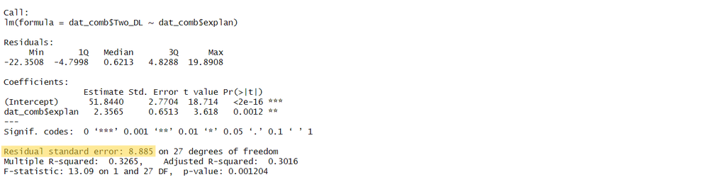

This shows where we can find the residual standard error on the linear model summary.